# Machine Learning Process 1 (Elipses)

> Rios Zambrano Angel

# Ejercicio 4

1. Para el dataset Cophasaurus texanus ya estandarizo de la tarea anterior:

**a) Descomponga la matriz de covarianzas en su forma espectral para el data set completo, luego por machos y por hembras por separado.**

```python
import pandas as pd
pd.set_option('max_row',6)
#cargamos la base de datos
lizard=pd.read_csv('data\lizard.csv')
lizard
```

|  | lizard | mass | svl | hls | sex | dummsex |
| --- | --- | --- | --- | --- | --- | --- |
| 0 | 1 | 5.526 | 59.0 | 113.5 | f | 1 |
| 1 | 2 | 10.401 | 75.0 | 142.0 | m | 0 |
| 2 | 3 | 9.213 | 69.0 | 124.0 | f | 1 |
| ... | ... | ... | ... | ... | ... | ... |
| 22 | 23 | 12.132 | 75.0 | 141.0 | m | 0 |
| 23 | 24 | 6.978 | 66.5 | 117.0 | f | 1 |
| 24 | 25 | 6.890 | 63.0 | 117.0 | f | 1 |

25 rows × 6 columns

Después de importar el data set, vamos a sacar las matrices de covarianzas para después poder sacar su descomposición espectral.

### Data set completo

```python
var_lizard=lizard[['mass','svl','hls']]
#Normalizamos las variables
norm_lizard=(var_lizard-var_lizard.mean())/var_lizard.std()
normliz_cov=norm_lizard.cov()
normliz_cov
```

|  | mass | svl | hls |
| --- | --- | --- | --- |
| mass | 1.000000 | 0.965945 | 0.918624 |
| svl | 0.965945 | 1.000000 | 0.938215 |
| hls | 0.918624 | 0.938215 | 1.000000 |

```python
import numpy as np

E = np.matrix([[1,0.965945,0.918624],
               [0.965945,1,0.938215],
               [0.918624,0.938215,1]])
# denotaremos a la matriz Gamma como "P" y a la matriz Lambda como "D"
#"d" es el vector de los valores propios y "D" los pone en la diagonal
(d,P)=np.linalg.eig(E)
D=np.real(np.diag(d))
E1=np.matmul(np.matmul(P,D) , np.transpose(P))

print('Matrix E\n',E)
print('Matrix P\n',P)
print('Matrix D\n',D)
print('PDP*\n',E1)
```

```
Matrix E
 [[1.       0.965945 0.918624]
 [0.965945 1.       0.938215]
 [0.918624 0.938215 1.      ]]
Matrix P
 [[-0.57794499 -0.6069095  -0.54556434]
 [-0.58188106  0.77519451 -0.24594289]
 [-0.57218356 -0.17531209  0.80116893]]
Matrix D
 [[2.8819899  0.         0.        ]
 [0.         0.03156999 0.        ]
 [0.         0.         0.0864401 ]]
PDP*
 [[1.       0.965945 0.918624]
 [0.965945 1.       0.938215]
 [0.918624 0.938215 1.      ]]
```

```python
#Agregamos la columna dummy se sexo
norm_lizard[['dummsex']]=lizard[['dummsex']]
norm_lizard
```

|  | mass | svl | hls | dummsex |
| --- | --- | --- | --- | --- |
| 0 | -1.178988 | -1.181519 | -1.159032 | 1 |
| 1 | 0.639517 | 0.833865 | 0.931627 | 0 |
| 2 | 0.196361 | 0.078096 | -0.388789 | 1 |
| ... | ... | ... | ... | ... |
| 22 | 1.285226 | 0.833865 | 0.858270 | 0 |
| 23 | -0.637353 | -0.236808 | -0.902284 | 1 |
| 24 | -0.670179 | -0.677673 | -0.902284 | 1 |

25 rows × 4 columns

### Hembras

```python
normliz_covh=norm_lizard[norm_lizard['dummsex']==1].cov().drop(['dummsex'],axis=1).drop(['dummsex'],axis=0)
normliz_covh
```

|  | mass | svl | hls |
| --- | --- | --- | --- |
| mass | 0.561752 | 0.550588 | 0.397277 |
| svl | 0.550588 | 0.604692 | 0.414124 |
| hls | 0.397277 | 0.414124 | 0.331920 |

```python
import numpy as np

Eh = np.matrix([[0.561752,0.550588,0.397277],
               [0.550588,0.604692,0.414124],
               [0.397277,0.414124,0.331920]])
# denotaremos a la matriz Gamma como "P" y a la matriz Lambda como "D"
#"d" es el vector de los valores propios y "D" los pone en la diagonal
(d1,P1)=np.linalg.eig(Eh)
D1=np.real(np.diag(d1))
E2=np.matmul(np.matmul(P1,D1) , np.transpose(P1))

print('Matrix E\n',Eh)
print('Matrix P\n',P1)
print('Matrix D\n',D1)
print('PDP*\n',E2)
```

```
Matrix E
 [[0.561752 0.550588 0.397277]
 [0.550588 0.604692 0.414124]
 [0.397277 0.414124 0.33192 ]]
Matrix P
 [[-0.6145704  -0.64719412  0.45104656]
 [-0.63934988  0.07371192 -0.76537461]
 [-0.46209844  0.75875314  0.45908465]]
Matrix D
 [[1.4332542  0.         0.        ]
 [0.         0.03328603 0.        ]
 [0.         0.         0.03182377]]
PDP*
 [[0.561752 0.550588 0.397277]
 [0.550588 0.604692 0.414124]
 [0.397277 0.414124 0.33192 ]]
```

### Machos

```python
normliz_covm=norm_lizard[norm_lizard['dummsex']==0].cov().drop(['dummsex'],axis=1).drop(['dummsex'],axis=0)
normliz_covm
```

|  | mass | svl | hls |
| --- | --- | --- | --- |
| mass | 0.734278 | 0.619208 | 0.477049 |
| svl | 0.619208 | 0.576170 | 0.424911 |
| hls | 0.477049 | 0.424911 | 0.374353 |

```python
import numpy as np

Em = np.matrix([[0.734278,0.619208,0.477049],
               [0.619208,0.576170,0.424911],
               [0.477049,0.424911,0.374353]])
# denotaremos a la matriz Gamma como "P" y a la matriz Lambda como "D"
#"d" es el vector de los valores propios y "D" los pone en la diagonal
(d2,P2)=np.linalg.eig(Em)
D2=np.real(np.diag(d2))
E3=np.matmul(np.matmul(P2,D2) , np.transpose(P2))

print('Matrix E\n',Em)
print('Matrix P\n',P2)
print('Matrix D\n',D2)
print('PDP*\n',E3)
```

```
Matrix E
 [[0.734278 0.619208 0.477049]
 [0.619208 0.57617  0.424911]
 [0.477049 0.424911 0.374353]]
Matrix P
 [[-0.66598252 -0.56444561 -0.48771758]
 [-0.58778645  0.79964004 -0.12281248]
 [-0.45931947 -0.20488282  0.86431976]]
Matrix D
 [[1.60979642 0.         0.        ]
 [0.         0.0302166  0.        ]
 [0.         0.         0.04478798]]
PDP*
 [[0.734278 0.619208 0.477049]
 [0.619208 0.57617  0.424911]
 [0.477049 0.424911 0.374353]]
```

**b) Implementar un metodo en python que calcule las elipsoides de confianza en 3 dimensiones, luego haga un scatter plot y aplique este método para graficar los elipsoides junto con los datos al (1-0.05)% para hembras y machos por separado pero deben aparecer en el mismo plot.**

```python
import math
import numpy as np
from matplotlib import pyplot as plt
from mpl_toolkits.mplot3d import Axes3D
import nestle

def plot_ellipsoid_3d(ell, ax,color):
    """Plot the 3-d Ellipsoid ell on the Axes3D ax."""

    # points on unit sphere
    u = np.linspace(0, 2.0 * np.pi, 100)
    v = np.linspace(0, np.pi, 100)
    z = np.outer(np.cos(u), np.sin(v))
    y = np.outer(np.sin(u), np.sin(v))
    x = np.outer(np.ones_like(u), np.cos(v))

    # transform points to ellipsoid
    for i in range(len(x)):
        for j in range(len(x)):
            x[i,j], y[i,j], z[i,j] = ell.ctr + np.dot(ell.axes,
                                                      [x[i,j],y[i,j],z[i,j]])

    ax.plot_wireframe(x, y, z,  rstride=4, cstride=4, color=color, alpha=0.1)
```

```python
##Hembras
lizard_h=norm_lizard[norm_lizard['dummsex']==1]

##Machos
lizard_m=norm_lizard[norm_lizard['dummsex']==0]
```

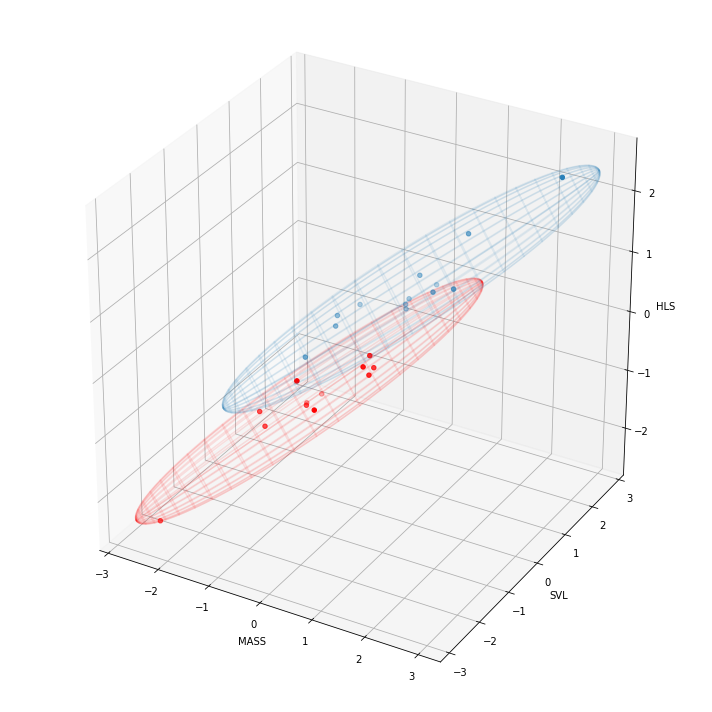

```python
#Pasamos los puntos a un _array_
columns=lizard_h[['mass','svl','hls']]
h1=columns.values.tolist()
h=np.asarray(h1)

columns1=lizard_m[['mass','svl','hls']]
m1=columns1.values.tolist()
m=np.asarray(m1)


B_npoints = len(h) #hembras
npoints = len(m) #machos


#Hembras
B_points = h
B_pointvol = 0.13

#Machos
points = m
pointvol = 0.12

# Find bounding ellipsoid(s)
B_ells = nestle.bounding_ellipsoids(B_points, B_pointvol)#Hembras
ells = nestle.bounding_ellipsoids(points, pointvol)#Machos

# plot
fig = plt.figure(figsize=(10., 10.))
ax = fig.add_subplot(111, projection='3d')

for ell in B_ells:
    plot_ellipsoid_3d(ell, ax,'Red')
    ax.scatter(B_points[:, 0], B_points[:, 1], B_points[:, 2], c='Red', marker='o')#hembras

for ell in ells:
    plot_ellipsoid_3d(ell, ax,'#2980b9')
    ax.scatter(points[:, 0], points[:, 1], points[:, 2], c='#2980b9', marker='o')  #machos


ax.set_xlabel('MASS')
ax.set_ylabel('SVL')
ax.set_zlabel('HLS')

#ax.view_init(elev=None, azim=90)

fig.tight_layout()
plt.show()
```

Ahora que ya ajustamos la elipse, vamos a hacerla elipse con el $95\%$ de confianza

```python
from __future__ import division
from mpl_toolkits.mplot3d import Axes3D
import matplotlib.pyplot as plt
import sys
import numpy as np
from numpy import linalg
from random import random

class EllipsoidTool:
    """Some stuff for playing with ellipsoids"""
    def __init__(self): pass

    def getMinVolEllipse(self, P=None, tolerance=0.05):
        """ Find the minimum volume ellipsoid which holds all the points

        Based on work by Nima Moshtagh
        http://www.mathworks.com/matlabcentral/fileexchange/9542
        and also by looking at:
        http://cctbx.sourceforge.net/current/python/scitbx.math.minimum_covering_ellipsoid.html
        Which is based on the first reference anyway!

        Here, P is a numpy array of N dimensional points like this:
        P = [[x,y,z,...], <-- one point per line
             [x,y,z,...],
             [x,y,z,...]]

        Returns:
        (center, radii, rotation)

        """
        (N, d) = np.shape(P)
        d = float(d)

        # Q will be our working array
        Q = np.vstack([np.copy(P.T), np.ones(N)])
        QT = Q.T

        # initializations
        err = 1.0 + tolerance
        u = (1.0 / N) * np.ones(N)

        # Khachiyan Algorithm
        while err > tolerance:
            V = np.dot(Q, np.dot(np.diag(u), QT))
            M = np.diag(np.dot(QT , np.dot(linalg.inv(V), Q)))    # M the diagonal vector of an NxN matrix
            j = np.argmax(M)
            maximum = M[j]
            step_size = (maximum - d - 1.0) / ((d + 1.0) * (maximum - 1.0))
            new_u = (1.0 - step_size) * u
            new_u[j] += step_size
            err = np.linalg.norm(new_u - u)
            u = new_u

        # center of the ellipse
        center = np.dot(P.T, u)

        # the A matrix for the ellipse
        A = linalg.inv(
                       np.dot(P.T, np.dot(np.diag(u), P)) -
                       np.array([[a * b for b in center] for a in center])
                       ) / d

        # Get the values we'd like to return
        U, s, rotation = linalg.svd(A)
        radii = 1.0/np.sqrt(s)

        return (center, radii, rotation)

    def getEllipsoidVolume(self, radii):
        """Calculate the volume of the blob"""
        return 4./3.*np.pi*radii[0]*radii[1]*radii[2]

    def plotEllipsoid(self, center, radii, rotation, ax=None, plotAxes=False, cageColor='b', cageAlpha=0.2):
        """Plot an ellipsoid"""
        make_ax = ax == None
        if make_ax:
            fig = plt.figure()
            ax = fig.add_subplot(111, projection='3d')

        u = np.linspace(0.0, 2.0 * np.pi, 100)
        v = np.linspace(0.0, np.pi, 100)

        # cartesian coordinates that correspond to the spherical angles:
        x = radii[0] * np.outer(np.cos(u), np.sin(v))
        y = radii[1] * np.outer(np.sin(u), np.sin(v))
        z = radii[2] * np.outer(np.ones_like(u), np.cos(v))
        # rotate accordingly
        for i in range(len(x)):
            for j in range(len(x)):
                [x[i,j],y[i,j],z[i,j]] = np.dot([x[i,j],y[i,j],z[i,j]], rotation) + center

        if plotAxes:
            # make some purdy axes
            axes = np.array([[radii[0],0.0,0.0],
                             [0.0,radii[1],0.0],
                             [0.0,0.0,radii[2]]])
            # rotate accordingly
            for i in range(len(axes)):
                axes[i] = np.dot(axes[i], rotation)


            # plot axes
            for p in axes:
                X3 = np.linspace(-p[0], p[0], 100) + center[0]
                Y3 = np.linspace(-p[1], p[1], 100) + center[1]
                Z3 = np.linspace(-p[2], p[2], 100) + center[2]
                ax.plot(X3, Y3, Z3, color=cageColor)

        # plot ellipsoid
        ax.plot_wireframe(x, y, z,  rstride=4, cstride=4, color=cageColor, alpha=cageAlpha)

        if make_ax:
            plt.show()
            plt.close(fig)
            del fig
```

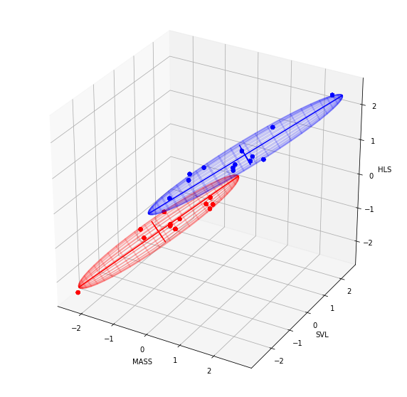

```python
##Hembras
lizard_h=norm_lizard[norm_lizard['dummsex']==1]
lizard_h1=lizard_h.drop(['dummsex'],axis=1)
lh1=np.asarray(lizard_h1)


##Machos
lizard_m=norm_lizard[norm_lizard['dummsex']==0]
lizard_m1=lizard_m.drop(['dummsex'],axis=1)
lm1=np.asarray(lizard_m1)

##Hembras

P = lh1

    # find the ellipsoid
ET = EllipsoidTool()
(center, radii, rotation) = ET.getMinVolEllipse(P, .05) ##95% confianza



fig = plt.figure(figsize=(10, 10))
ax = fig.add_subplot(111, projection='3d')

    # plot points
for x in P:
     ax.scatter(P[:,0], P[:,1], P[:,2], color='Red', marker='.', s=100)


ET.plotEllipsoid(center, radii, rotation, ax=ax, plotAxes=True,cageColor='Red')
#######
#MACHOS

P1= lm1
ET1 = EllipsoidTool()
(center, radii, rotation) = ET1.getMinVolEllipse(P1, .05) ##95% confianza

for r in P1:
     ax.scatter(P1[:,0], P1[:,1], P1[:,2], color='Blue', marker='.', s=100)

    # plot ellipsoid
ET1.plotEllipsoid(center, radii, rotation, ax=ax, plotAxes=True)


ax.set_xlabel('MASS')
ax.set_ylabel('SVL')
ax.set_zlabel('HLS')

plt.show()
```

Vemos que con un nivel del $95\%$ de coanfianza solo se sale un punto.

**c) Para cada uno de los siguientes subespacios encuentre la matriz de proyección de un vector sobre el subespacio.**

> i. $W_1=\{x\in \mathbb{R}^3: x+y-z=0\}$

> ii. $W_2=\{x\in \mathbb{R}^3: x-y+z=0\}$

Para $W_1=\{x\in \mathbb{R}^3: x+y-z=0\}$, primero debemos encontrar una base del plano;

Sea: $x+y-z=0 \Rightarrow z=x+y$ Hacemos a $x$ y $y$ constantes para llegar a la ecuación vectorial del plano

$$x=\alpha$$$$y=\beta$$$$\Rightarrow z=\alpha+\beta$$$$\Rightarrow (x,y,z)=(\alpha,\beta,\alpha+\beta)=(\alpha,0,\alpha)+(0,\beta,\beta)=\alpha(1,0,1)+\beta(0,1,1)$$

y como $\not\exists$ $\gamma\neq0$ tal que $(1,0,1)=\gamma(0,1,1)$, estos vectores son $l.i$ y son base del plano $W_1$.

> Recordemos que la matriz de Proyección sobre un subespacio (V), está dada por: $$Proy_{V}(\vec{x})=A(A^TA)^{-1}A^T\vec{x}$$ donde $A$ es la matriz de vectores base de $V$

$$\Rightarrow A_{W_1}=\begin{pmatrix}1&0\\ 0&1\\ 1&1\end{pmatrix}$$$$A_{W_1}^T=\begin{pmatrix}1&0&1\\ 0&1&1\end{pmatrix}$$$$A_{W_1}^TA_{W_1}=\begin{pmatrix}1&0&1\\ 0&1&1\end{pmatrix}\begin{pmatrix}1&0\\ 0&1\\ 1&1\end{pmatrix}=\begin{pmatrix}2&1\\ 1&2\end{pmatrix}$$$$(A_{W_1}^TA_{W_1})^{-1}=\begin{pmatrix}2&1\\ 1&2\end{pmatrix}^{-1}=\begin{pmatrix}\frac{2}{3}&-\frac{1}{3}\\ -\frac{1}{3}&\frac{2}{3}\end{pmatrix}$$$$\Rightarrow Proy_{W_1}(\vec{x})=A_{W_1}(A_{W_1}^TA_{W_1})^{-1}A_{W_1}^T\vec{x}$$$$Proy_{W_1}(\vec{x})=\begin{pmatrix}1&0\\ 0&1\\ 1&1\end{pmatrix}\begin{pmatrix}\frac{2}{3}&-\frac{1}{3}\\ -\frac{1}{3}&\frac{2}{3}\end{pmatrix}\begin{pmatrix}1&0&1\\ 0&1&1\end{pmatrix}\begin{pmatrix}x_1\\ x_2\\ x_3\end{pmatrix}$$$$Proy_{W_1}(\vec{x})=\begin{pmatrix}1&0\\ 0&1\\ 1&1\end{pmatrix}\begin{pmatrix}\frac{2}{3}&-\frac{1}{3}&\frac{1}{3}\\ -\frac{1}{3}&\frac{2}{3}&\frac{1}{3}\end{pmatrix}\begin{pmatrix}x_1\\ x_2\\ x_3\end{pmatrix}$$$$Proy_{W_1}(\vec{x})=\begin{pmatrix}\frac{2}{3}&-\frac{1}{3}&\frac{1}{3}\\ -\frac{1}{3}&\frac{2}{3}&\frac{1}{3}\\ \frac{1}{3}&\frac{1}{3}&\frac{2}{3}\end{pmatrix}\begin{pmatrix}x_1\\ x_2\\ x_3\end{pmatrix}$$

$$\therefore Proy_{W_1}= \begin{pmatrix}\frac{2}{3}&-\frac{1}{3}&\frac{1}{3}\\ -\frac{1}{3}&\frac{2}{3}&\frac{1}{3}\\ \frac{1}{3}&\frac{1}{3}&\frac{2}{3}\end{pmatrix}$$

Para $W_2=\{x\in \mathbb{R}^3: x-y+z=0\}$, primero debemos encontrar una base del plano;

Sea: $x-y+z=0 \Rightarrow z=y-x$ Hacemos a $x$ y $y$ constantes para llegar a la ecuación vectorial del plano

$$x=\alpha$$$$y=\beta$$$$\Rightarrow z=\beta-\alpha$$$$\Rightarrow (x,y,z)=(\alpha,\beta,\beta-\alpha)=(\alpha,0,-\alpha)+(0,\beta,\beta)=\alpha(1,0,-1)+\beta(0,1,1)$$

y como $\not\exists$ $\gamma\neq0$ tal que $(1,0,-1)=\gamma(0,1,1)$, estos vectores son $l.i$ y son base del plano $W_2$.

$$\Rightarrow A_{W_2}=\begin{pmatrix}1&0\\ 0&1\\ -1&1\end{pmatrix}$$$$A_{W_2}^T=\begin{pmatrix}1&0&-1\\ 0&1&1\end{pmatrix}$$$$A_{W_2}^TA_{W_2}=\begin{pmatrix}1&0&-1\\ 0&1&1\end{pmatrix}\begin{pmatrix}1&0\\ 0&1\\ -1&1\end{pmatrix}=\begin{pmatrix}2&-1\\ -1&2\end{pmatrix}$$$$(A_{W_2}^TA_{W_2})^{-1}=\begin{pmatrix}2&-1\\ -1&2\end{pmatrix}^{-1}=\begin{pmatrix}\frac{2}{3}&\frac{1}{3}\\ \frac{1}{3}&\frac{2}{3}\end{pmatrix}$$$$\Rightarrow Proy_{W_2}(\vec{x})=A_{W_2}(A_{W_2}^TA_{W_2})^{-1}A_{W_2}^T\vec{x}$$$$Proy_{W_2}(\vec{x})=\begin{pmatrix}1&0\\ 0&1\\ -1&1\end{pmatrix}\begin{pmatrix}\frac{2}{3}&\frac{1}{3}\\ \frac{1}{3}&\frac{2}{3}\end{pmatrix}\begin{pmatrix}1&0&-1\\ 0&1&1\end{pmatrix}\begin{pmatrix}x_1\\ x_2\\ x_3\end{pmatrix}$$$$Proy_{W_2}(\vec{x})=\begin{pmatrix}1&0\\ 0&1\\ -1&1\end{pmatrix} \begin{pmatrix}\frac{2}{3}&\frac{1}{3}&-\frac{1}{3}\\ \frac{1}{3}&\frac{2}{3}&\frac{1}{3}\end{pmatrix}\begin{pmatrix}x_1\\ x_2\\ x_3\end{pmatrix}$$$$Proy_{W_2}(\vec{x})=\begin{pmatrix}\frac{2}{3}&\frac{1}{3}&-\frac{1}{3}\\ \frac{1}{3}&\frac{2}{3}&\frac{1}{3}\\ -\frac{1}{3}&\frac{1}{3}&\frac{2}{3}\end{pmatrix}\begin{pmatrix}x_1\\ x_2\\ x_3\end{pmatrix}$$

$$\therefore Proy_{W_2}=\begin{pmatrix}\frac{2}{3}&\frac{1}{3}&-\frac{1}{3}\\ \frac{1}{3}&\frac{2}{3}&\frac{1}{3}\\ -\frac{1}{3}&\frac{1}{3}&\frac{2}{3}\end{pmatrix}$$

**d) Proyecte los datos y grafique, tanto en $\mathbb{R}^3$. Use diferentes marcadores para hembras y machos, use distintos marcadores para los puntos en el plano y fuera del plano.**

Primero vamos a proyectar sobre $W_1$

```python
#Vamos a proyectar los puntos en W1

import numpy as np

w1=np.matrix([[2/3,-1/3,1/3],
              [-1/3,2/3,1/3],
              [1/3,1/3,2/3]])

#Pasamos los puntos a un _array_
columns=lizard_h[['mass','svl','hls']]
h1=columns.values.tolist() ##lista de hembras

columns1=lizard_m[['mass','svl','hls']]
m1=columns1.values.tolist() ##lista machos


##vamos a aplicar la transformación a toda la lista
#Hembras
h1pts=[]
for x in h1:
    d2=np.asmatrix(x)
    d2t=np.transpose(d2)

    pp=np.matmul(w1,d2t)
    pp2=np.transpose(pp)
    ppp=pp2.tolist()

    h1pts=h1pts+ppp
    h1pts

proy_h1=np.asarray(h1pts) ##array Hembras

##Machos
m1pts=[]
for x in m1:
    d2=np.asmatrix(x)
    d2t=np.transpose(d2)

    pp=np.matmul(w1,d2t)
    pp2=np.transpose(pp)
    ppp=pp2.tolist()

    m1pts=m1pts+ppp
    m1pts

proy_m1=np.asarray(m1pts) ##array machos

##los hacemos dataframes
import pandas as pd

h1proy=pd.DataFrame(proy_h1)#hembras
m1proy=pd.DataFrame(proy_m1)#mchos

import seaborn as sb
h1proy.columns=('mass','svl','hls')
m1proy.columns=('mass','svl','hls')
```

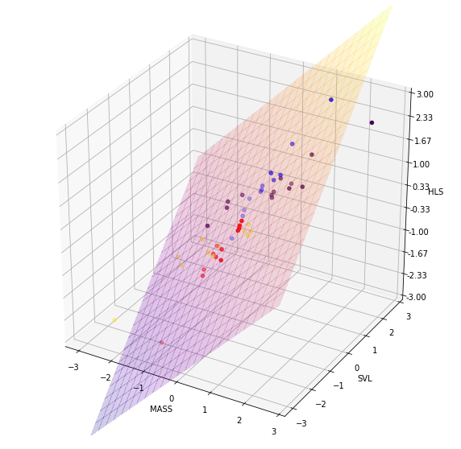

```python
from mpl_toolkits.mplot3d import Axes3D
from matplotlib import cm
from matplotlib.ticker import LinearLocator, FormatStrFormatter
import matplotlib.pyplot as plt
import numpy as np

fig = plt.figure(figsize=(10., 10.))

ax = fig.gca(projection='3d')
X = np.arange(-3, 3, 0.25)
Y = np.arange(-3, 3, 0.25)
X, Y = np.meshgrid(X, Y)
Z = X+Y
surf = ax.plot_surface(X, Y, Z, rstride=1, cstride=1, cmap='plasma',
                       linewidth=0, antialiased=False,alpha=0.2)

ax.set_zlim(-3, 3)

ax.zaxis.set_major_locator(LinearLocator(10))
ax.zaxis.set_major_formatter(FormatStrFormatter('%.02f'))

ax.view_init(elev=None, azim=None)


 ##############
columns3=norm_lizard[['mass','svl','hls','dummsex']]

#fig = plt.figure()
#ax = fig.add_subplot(111, projection='3d')

m = columns3['dummsex']
xs = columns3['mass']
ys =columns3['svl']
zs =columns3['hls']


ax.scatter(xs, ys, zs,c=m, marker='o')

ax.set_xlabel('MASS')
ax.set_ylabel('SVL')
ax.set_zlabel('HLS')
#######################
#hembras
columns4=h1proy[['mass','svl','hls']]

x1h = columns4['mass']
y1h =columns4['svl']
z1h =columns4['hls']

ax.scatter(x1h, y1h, z1h,c='Red', marker='o')

#machos
columns5=m1proy[['mass','svl','hls']]

x1m = columns5['mass']
y1m =columns5['svl']
z1m =columns5['hls']

ax.scatter(x1m, y1m, z1m,c='Blue', marker='o')



#fig.colorbar(surf, shrink=0.5, aspect=5)

plt.show()
```

Hembras=Puntos amarillos, y rojos para la proyección.

Machos=Puntos morados, y azules para la proyección

## La siguiente entrada es la misma gráfica, solo que rotada para ver que efectivamente los puntos están proyectados

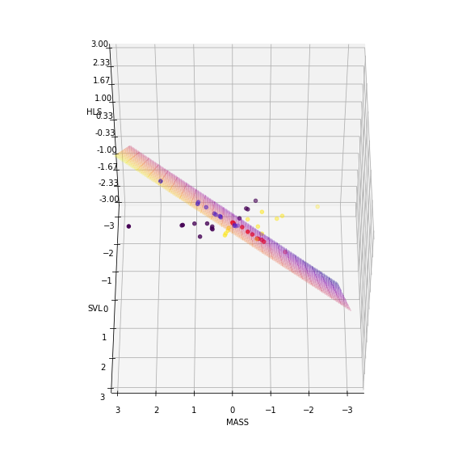

```python
from mpl_toolkits.mplot3d import Axes3D
from matplotlib import cm
from matplotlib.ticker import LinearLocator, FormatStrFormatter
import matplotlib.pyplot as plt
import numpy as np

fig = plt.figure(figsize=(10, 10))

ax = fig.gca(projection='3d')
X = np.arange(-3, 3, 0.25)
Y = np.arange(-3, 3, 0.25)
X, Y = np.meshgrid(X, Y)
Z = X+Y
#Z1=Y-X
surf = ax.plot_surface(X, Y, Z, rstride=1, cstride=1, cmap='plasma',
                       linewidth=0, antialiased=False,alpha=0.2)

#surf1 = ax.plot_surface(X, Y, Z1, rstride=1, cstride=1,cmap='viridis',
 #                      linewidth=0, antialiased=False,alpha=0.2)
ax.set_zlim(-3, 3)

ax.zaxis.set_major_locator(LinearLocator(10))
ax.zaxis.set_major_formatter(FormatStrFormatter('%.02f'))


 ##############
columns3=norm_lizard[['mass','svl','hls','dummsex']]

m = columns3['dummsex']
xs = columns3['mass']
ys =columns3['svl']
zs =columns3['hls']


ax.scatter(xs, ys, zs,c=m, marker='o')

ax.set_xlabel('MASS')
ax.set_ylabel('SVL')
ax.set_zlabel('HLS')
#######################
#hembras
columns4=h1proy[['mass','svl','hls']]

x1h = columns4['mass']
y1h =columns4['svl']
z1h =columns4['hls']

ax.scatter(x1h, y1h, z1h,c='Red', marker='o')

#machos
columns5=m1proy[['mass','svl','hls']]

x1m = columns5['mass']
y1m =columns5['svl']
z1m =columns5['hls']

ax.scatter(x1m, y1m, z1m,c='Blue', marker='o')

ax.view_init(elev=50, azim=90)

plt.show()
```

Ahora vamos a proyectarlos sobre $W_2$

```python
import numpy as np

w2=np.matrix([[2/3,1/3,-1/3],
              [1/3,2/3,1/3],
              [-1/3,1/3,2/3]])

#Pasamos los puntos a un _array_
columns=lizard_h[['mass','svl','hls']]
h1=columns.values.tolist() ##lista de hembras

columns1=lizard_m[['mass','svl','hls']]
m1=columns1.values.tolist() ##lista machos


##vamos a aplicar la transformación a toda la lista
#Hembras
h2pts=[]
for x in h1:
    d2=np.asmatrix(x)
    d2t=np.transpose(d2)

    pp=np.matmul(w2,d2t)
    pp2=np.transpose(pp)
    ppp=pp2.tolist()

    h2pts=h2pts+ppp
    h2pts

proy_h2=np.asarray(h2pts) ##array Hembras

##Machos
m2pts=[]
for x in m1:
    d2=np.asmatrix(x)
    d2t=np.transpose(d2)

    pp=np.matmul(w2,d2t)
    pp2=np.transpose(pp)
    ppp=pp2.tolist()

    m2pts=m2pts+ppp
    m2pts

proy_m2=np.asarray(m2pts) ##array machos

##los hacemos dataframes
import pandas as pd

h2proy=pd.DataFrame(proy_h2)#hembras
m2proy=pd.DataFrame(proy_m2)#mchos

import seaborn as sb
h2proy.columns=('mass','svl','hls')
m2proy.columns=('mass','svl','hls')
```

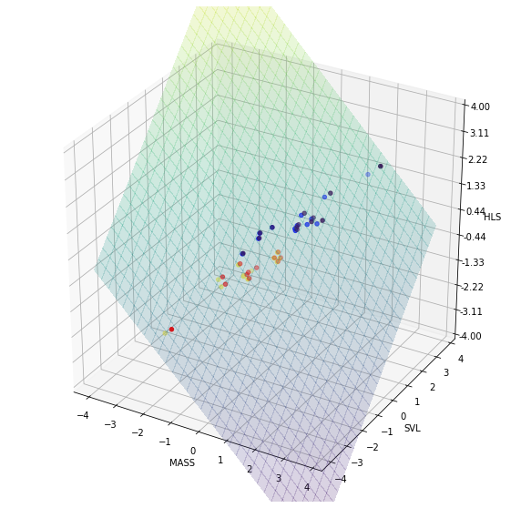

```python
fig = plt.figure(figsize=(10., 10.))

ax = fig.gca(projection='3d')
X = np.arange(-4, 4, 0.25)
Y = np.arange(-4, 4, 0.25)
X, Y = np.meshgrid(X, Y)

Z1=Y-X

surf1 = ax.plot_surface(X, Y, Z1, rstride=1, cstride=1,cmap='viridis',
                       linewidth=0, antialiased=False,alpha=0.2)
ax.set_zlim(-4, 4)

ax.zaxis.set_major_locator(LinearLocator(10))
ax.zaxis.set_major_formatter(FormatStrFormatter('%.02f'))

 ##############
columns3=norm_lizard[['mass','svl','hls','dummsex']]

m = columns3['dummsex']
xs = columns3['mass']
ys =columns3['svl']
zs =columns3['hls']


ax.scatter(xs, ys, zs,c=m, marker='o')

ax.set_xlabel('MASS')
ax.set_ylabel('SVL')
ax.set_zlabel('HLS')
#######################
#hembras
columns6=h2proy[['mass','svl','hls']]

x2h = columns6['mass']
y2h =columns6['svl']
z2h =columns6['hls']

ax.scatter(x2h, y2h, z2h,c='Red', marker='o')

#machos
columns7=m2proy[['mass','svl','hls']]

x2m = columns7['mass']
y2m =columns7['svl']
z2m =columns7['hls']

ax.scatter(x2m, y2m, z2m,c='Blue', marker='o')


plt.show()
```

Hembras=Puntos amarillos, y rojos para la proyección.

Machos=Puntos morados, y azules para la proyección

## La siguiente entrada es la misma gráfica, solo que rotada para ver que efectivamente los puntos están proyectados

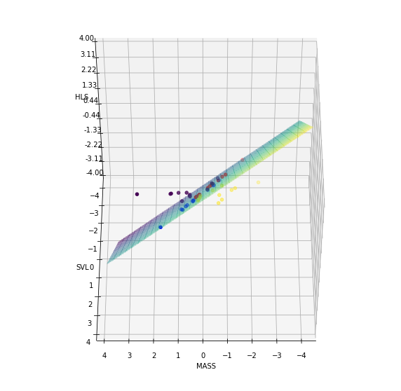

```python
fig = plt.figure(figsize=(10., 10.))

ax = fig.gca(projection='3d')
X = np.arange(-4, 4, 0.25)
Y = np.arange(-4, 4, 0.25)
X, Y = np.meshgrid(X, Y)

Z1=Y-X

surf1 = ax.plot_surface(X, Y, Z1, rstride=1, cstride=1,cmap='viridis',
                       linewidth=0, antialiased=False,alpha=0.2)
ax.set_zlim(-4, 4)

ax.zaxis.set_major_locator(LinearLocator(10))
ax.zaxis.set_major_formatter(FormatStrFormatter('%.02f'))

ax.view_init(elev=None, azim=None)


 ##############
columns3=norm_lizard[['mass','svl','hls','dummsex']]

#fig = plt.figure()
#ax = fig.add_subplot(111, projection='3d')

m = columns3['dummsex']
xs = columns3['mass']
ys =columns3['svl']
zs =columns3['hls']


ax.scatter(xs, ys, zs,c=m, marker='o')

ax.set_xlabel('MASS')
ax.set_ylabel('SVL')
ax.set_zlabel('HLS')
#######################
#hembras
columns6=h2proy[['mass','svl','hls']]

x2h = columns6['mass']
y2h =columns6['svl']
z2h =columns6['hls']

ax.scatter(x2h, y2h, z2h,c='Red', marker='o')

#machos
columns7=m2proy[['mass','svl','hls']]

x2m = columns7['mass']
y2m =columns7['svl']
z2m =columns7['hls']

ax.scatter(x2m, y2m, z2m,c='Blue', marker='o')

ax.view_init(elev=50, azim=90)

plt.show()
```

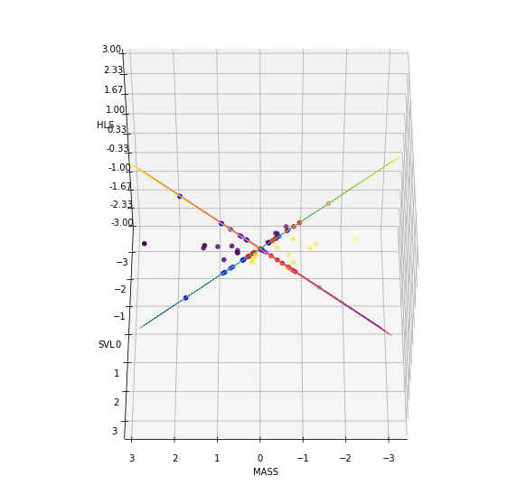

```python
from mpl_toolkits.mplot3d import Axes3D
from matplotlib import cm
from matplotlib.ticker import LinearLocator, FormatStrFormatter
import matplotlib.pyplot as plt
import numpy as np

fig = plt.figure(figsize=(10., 10.))

ax = fig.gca(projection='3d')
X = np.arange(-3, 3, 0.25)
Y = np.arange(-3, 3, 0.25)
X, Y = np.meshgrid(X, Y)
Z = X+Y
Z1=Y-X
surf = ax.plot_surface(X, Y, Z, rstride=1, cstride=1, cmap='plasma',
                       linewidth=0, antialiased=False,alpha=0.2)

surf1 = ax.plot_surface(X, Y, Z1, rstride=1, cstride=1,cmap='viridis',
                      linewidth=0, antialiased=False,alpha=0.2)
ax.set_zlim(-3, 3)

ax.zaxis.set_major_locator(LinearLocator(10))
ax.zaxis.set_major_formatter(FormatStrFormatter('%.02f'))


 ##############
columns3=norm_lizard[['mass','svl','hls','dummsex']]

m = columns3['dummsex']
xs = columns3['mass']
ys =columns3['svl']
zs =columns3['hls']


ax.scatter(xs, ys, zs,c=m, marker='o')

ax.set_xlabel('MASS')
ax.set_ylabel('SVL')
ax.set_zlabel('HLS')
#######################
#hembras
columns4=h1proy[['mass','svl','hls']]

x1h = columns4['mass']
y1h =columns4['svl']
z1h =columns4['hls']

ax.scatter(x1h, y1h, z1h,c='Red', marker='o')

#machos
columns5=m1proy[['mass','svl','hls']]

x1m = columns5['mass']
y1m =columns5['svl']
z1m =columns5['hls']

ax.scatter(x1m, y1m, z1m,c='Blue', marker='o')
#######################
#hembras
columns6=h2proy[['mass','svl','hls']]

x2h = columns6['mass']
y2h =columns6['svl']
z2h =columns6['hls']

ax.scatter(x2h, y2h, z2h,c='Red', marker='o')

#machos
columns7=m2proy[['mass','svl','hls']]

x2m = columns7['mass']
y2m =columns7['svl']
z2m =columns7['hls']

ax.scatter(x2m, y2m, z2m,c='Blue', marker='o')


ax.view_init(elev=50, azim=90)


plt.show()
```

# **Ejericio 5**:

**Los datasets time series 1.csv y time series 2.csv contienen dos trayectorias de dos series de tiempo, para cada una de ellas:**

**a) Hacer un plot de los datasets e identicar el tipo serie utilizando los autocorrelogramas simples y parciales. Observara que existen anomalıas dentro de las series.**

```python
import pandas as pd
pd.set_option('max_row',6)
#cargamos las bases de datos
ts1=pd.read_csv('data/time_series_1.csv')
ts2=pd.read_csv('data/time_series_2.csv')
```

## Time Series 1

```
ts1
```

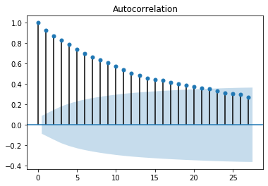

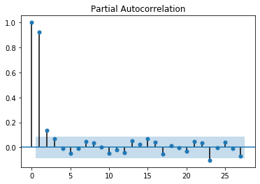

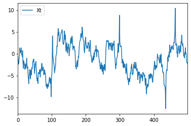

```python
import matplotlib.pyplot as plt
from statsmodels.graphics.tsaplots import plot_pacf
from statsmodels.graphics.tsaplots import plot_acf

print('ts1')
plot_acf(ts1)
plot_pacf(ts1)
ts1.plot()
```

Aunque la serie se mueva alrededor del 0, no es una serie estacionaria

## Time Series 2

```
ts2
```

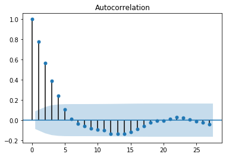

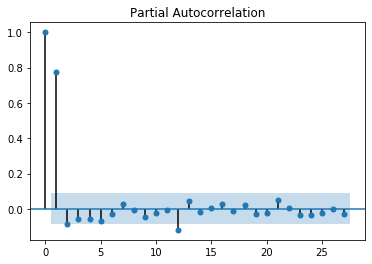

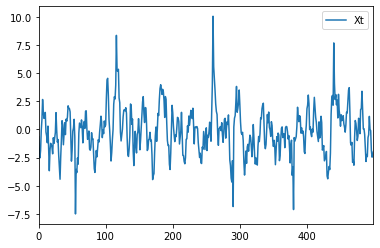

```python
print('ts2')
plot_acf(ts2)
plot_pacf(ts2)
ts2.plot()
```

**b) Ajusta un modelo estacionario adecuado para cada una de las trayectorias, y de la tabla con el resumen del ajuste y los parametros.**

## Time Series 1

```python
from statsmodels.tsa.arima_model import ARIMA

modelo = ARIMA(ts1,order = (2,0,0))
modelo_ajustado=modelo.fit(disp=0)
modelo_ajustado.summary()
```

ARMA Model Results

| Dep. Variable: | Xt | No. Observations: | 500 |
| --- | --- | --- | --- |
| Model: | ARMA(2, 0) | Log Likelihood | -835.016 |
| Method: | css-mle | S.D. of innovations | 1.283 |
| Date: | Wed, 22 Apr 2020 | AIC | 1678.032 |
| Time: | 15:06:47 | BIC | 1694.890 |
| Sample: | 0 | HQIC | 1684.647 |

|  | coef | std err | z | P>\|z\| | [0.025 | 0.975] |
| --- | --- | --- | --- | --- | --- | --- |
| const | -1.4103 | 0.818 | -1.725 | 0.085 | -3.013 | 0.192 |
| ar.L1.Xt | 0.8014 | 0.044 | 18.093 | 0.000 | 0.715 | 0.888 |
| ar.L2.Xt | 0.1305 | 0.044 | 2.947 | 0.003 | 0.044 | 0.217 |

Roots

|  | Real | Imaginary | Modulus | Frequency |
| --- | --- | --- | --- | --- |
| AR.1 | 1.0636 | +0.0000j | 1.0636 | 0.0000 |
| AR.2 | -7.2036 | +0.0000j | 7.2036 | 0.5000 |

## Time Series 2

```python
from statsmodels.tsa.arima_model import ARIMA

modelo = ARIMA(ts2,order = (2,0,0))
modelo_ajustado=modelo.fit(disp=0)
modelo_ajustado.summary()
```

ARMA Model Results

| Dep. Variable: | Xt | No. Observations: | 500 |
| --- | --- | --- | --- |
| Model: | ARMA(2, 0) | Log Likelihood | -837.385 |
| Method: | css-mle | S.D. of innovations | 1.290 |
| Date: | Wed, 22 Apr 2020 | AIC | 1682.770 |
| Time: | 15:06:49 | BIC | 1699.628 |
| Sample: | 0 | HQIC | 1689.385 |

|  | coef | std err | z | P>\|z\| | [0.025 | 0.975] |
| --- | --- | --- | --- | --- | --- | --- |
| const | -0.1660 | 0.236 | -0.703 | 0.482 | -0.629 | 0.297 |
| ar.L1.Xt | 0.8417 | 0.045 | 18.909 | 0.000 | 0.754 | 0.929 |
| ar.L2.Xt | -0.0848 | 0.045 | -1.902 | 0.058 | -0.172 | 0.003 |

Roots

|  | Real | Imaginary | Modulus | Frequency |
| --- | --- | --- | --- | --- |
| AR.1 | 1.3799 | +0.0000j | 1.3799 | 0.0000 |
| AR.2 | 8.5458 | +0.0000j | 8.5458 | 0.0000 |

**c) A partir del orden de la serie de tiempo, usar el numero de retrasos adecuado para generar matriz de datos $X_{(n−p)×p}$. A partir de esta matriz descomponerla para graficar las elipses o elipsoides de confianza.**

```python
import numpy as np
from matplotlib.patches import Ellipse
from scipy.stats import chi2

def computeMaximumLikelihoodEstimators(datasetPD,columns):
    mu =  list(datasetPD[columns].mean())
    sigma = np.matrix(datasetPD[columns].cov())
    return mu, sigma

def diagonalize(sigma):
    eigenValues, eigenVectors = np.linalg.eigh(sigma)
    idx = eigenValues.argsort()[::-1]
    eigenValues = eigenValues[idx]
    eigenVectors = eigenVectors[:,idx]
    return eigenValues, eigenVectors

def plotConfidenceEllipse(plt,mu,eigenValues,eigenVectors,chiSquaredCriticalVale,ax=None,**kwargs):
    if ax is None:
        ax = plt.gca()
    theta = np.degrees(np.arctan2(*eigenVectors[:,0][::-1]))
    width,height = chiSquaredCriticalVale*np.sqrt(eigenValues)
    confidenceEllipse = Ellipse(xy=mu,width=width,height=height,angle=theta,**kwargs)
    ax.add_artist(confidenceEllipse)
    return confidenceEllipse

def getProbabilityDensityContour(plt,datasetPD,columns,alpha,freedomDegrees,color,name='DataSet'):
    mu, sigma = computeMaximumLikelihoodEstimators(datasetPD,columns)
    eigenValues, eigenVectors = diagonalize(sigma)
    chiSquaredCriticalVale = chi2.ppf(q=(1-alpha),df=freedomDegrees)
    plotConfidenceEllipse(plt,mu,eigenValues,eigenVectors,chiSquaredCriticalVale,color=color,alpha=0.25)
    sumaryTable=[]
    sumaryTable.append(['Mean',mu])
    sumaryTable.append(['Covariance matrix',sigma])
    sumaryTable.append(['EigenValues',eigenValues])
    sumaryTable.append(['EigenVectors',eigenVectors])
    sumaryTable.append(['Confidence',1-alpha])
    sumaryTable.append(['Chi-squared critical value',chiSquaredCriticalVale])
    sumaryTableDF = pd.DataFrame(sumaryTable,columns=['Summary',name])
    return sumaryTableDF

def scatterPlot(plt,datasetPD,col_1,col_2,color):
    dataPD = datasetPD[[col_1,col_2]]
    plt.scatter(dataPD[col_1],dataPD[col_2],color=color)
```

## Time Series 1

```python
#Correr a partir de aqui en caso de que en el inciso d no se muestren correctamente los outliers
Xt=ts1[:len(ts1)-2]
Xt=Xt["Xt"].to_numpy()

Xt_1=ts1[1:len(ts1)-1]
Xt_1=Xt_1["Xt"].to_numpy()

Xt_2=ts1[2:]
Xt_2=Xt_2["Xt"].to_numpy()

df1=pd.concat([pd.DataFrame(Xt),pd.DataFrame(Xt_1),pd.DataFrame(Xt_2)], axis=1,ignore_index=True)
df1
```

|  | 0 | 1 | 2 |
| --- | --- | --- | --- |
| 0 | -0.643717 | -1.882663 | -2.408924 |
| 1 | -1.882663 | -2.408924 | -2.029307 |
| 2 | -2.408924 | -2.029307 | -0.784814 |
| ... | ... | ... | ... |
| 495 | 0.147971 | -1.591569 | -2.009989 |
| 496 | -1.591569 | -2.009989 | -2.103608 |
| 497 | -2.009989 | -2.103608 | -2.252820 |

498 rows × 3 columns

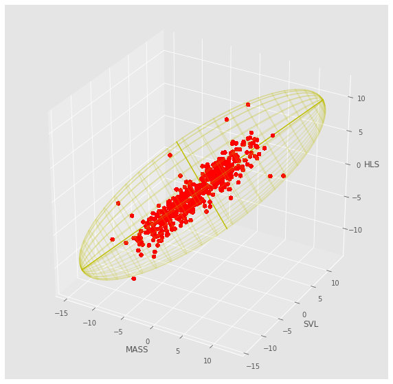

```python
fig = plt.figure(figsize=(10, 10))
ax = fig.add_subplot(111, projection='3d')

P1= np.array(df1)
ET1 = EllipsoidTool()
(center, radii, rotation) = ET1.getMinVolEllipse(P1, .05) ##95% confianza

for r in P1:
     ax.scatter(P1[:,0], P1[:,1], P1[:,2], color='r', marker='.', s=100)

    # plot ellipsoid
ET1.plotEllipsoid(center, radii, rotation, ax=ax, plotAxes=True,cageColor='y')


ax.set_xlabel('MASS')
ax.set_ylabel('SVL')
ax.set_zlabel('HLS')

plt.show()
```

## Time Series 2

```python
#Correr a partir de aqui en caso de que en el inciso d no se muestren correctamente los outliers
Xt=ts2[:len(ts2)-1]
Xt=Xt["Xt"].to_numpy()

Xt_1=ts2[1:]
Xt_1=Xt_1["Xt"].to_numpy()

df2=pd.concat([pd.DataFrame(Xt),pd.DataFrame(Xt_1)], axis=1,ignore_index=True)
df2
```

|  | 0 | 1 |
| --- | --- | --- |
| 0 | -0.643717 | -1.959909 |
| 1 | -1.959909 | -2.526699 |
| 2 | -2.526699 | -1.859958 |
| ... | ... | ... |
| 496 | -1.859832 | -2.463331 |
| 497 | -2.463331 | -2.285534 |
| 498 | -2.285534 | -1.966372 |

499 rows × 2 columns

|  | Summary | DataSet |
| --- | --- | --- |
| 0 | Mean | [-0.15094259987243697, -0.15359321113042357] |
| 1 | Covariance matrix | [[[[[4.23822543 3.29440181]]]], [[[[3.29440181... |
| 2 | EigenValues | [7.535690359087555, 0.9468838881414698] |
| 3 | EigenVectors | [[[[[ 0.70677813 -0.70743528]]]], [[[[0.707435... |
| 4 | Confidence | 0.95 |
| 5 | Chi-squared critical value | 5.99146 |

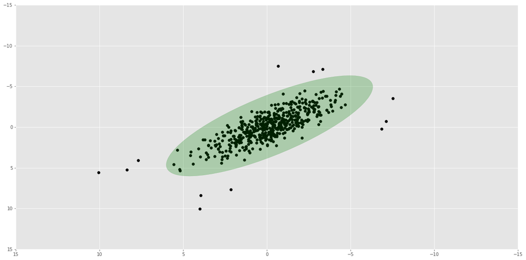

```python
import matplotlib.pyplot as plt

plt.style.use('ggplot')
col_1, col_2 = 0,1
cols=[col_1,col_2]
alpha=0.05
df=2
plt.figure(figsize=[20,10])
plt.axis([15,-15,15,-15])

scatterPlot(plt,df2,col_1, col_2,'black')
getProbabilityDensityContour(plt,df2,[col_1, col_2],alpha,df,'green','DataSet')
```

**d) Utilizar el metodo de la envolvente elíptica para identicar las anomalıas dentro de la series, use una confianza del 0.99. Utilizar el paquete de python sklearn.covariance.EllipticEnvelope para realizar dichatarea.¨**

## Time Series 1

```python
from sklearn.covariance import EllipticEnvelope

X=df1[:len(df1)-1]
e_v=EllipticEnvelope(contamination=0.01,random_state=0).fit(X)
labels=list(e_v.predict(X))
labels.append(1)
df1['label']=labels
df1[df1['label']==-1]
```

|  | 0 | 1 | 2 | label |
| --- | --- | --- | --- | --- |
| 298 | 2.350912 | 8.783942 | 2.749869 | -1 |
| 434 | -8.610623 | -12.605792 | -4.875014 | -1 |
| 435 | -12.605792 | -4.875014 | -4.041306 | -1 |
| 462 | 4.880163 | 10.386888 | 3.813626 | -1 |
| 463 | 10.386888 | 3.813626 | 1.935448 | -1 |

```python
# cambie el marcador a 10 porque voy a utilizar el tamaño para diferenciar los puntos en la grafica original
observaciones_outliers=[298,434,435,462,463]
for i in observaciones_outliers:
    df1['label'][i]=10
df1[df1['label']==10]
```

|  | 0 | 1 | 2 | label |
| --- | --- | --- | --- | --- |
| 298 | 2.350912 | 8.783942 | 2.749869 | 10 |
| 434 | -8.610623 | -12.605792 | -4.875014 | 10 |
| 435 | -12.605792 | -4.875014 | -4.041306 | 10 |
| 462 | 4.880163 | 10.386888 | 3.813626 | 10 |
| 463 | 10.386888 | 3.813626 | 1.935448 | 10 |

Se tienen un total de 5 outliers

## Time Series 2

```python
from sklearn.covariance import EllipticEnvelope

X=df2[:len(df2)-1]
e_v=EllipticEnvelope(contamination=0.01,random_state=0).fit(X)
labels=list(e_v.predict(X))
labels.append(1)
df2['label']=labels
df2[df2['label']==-1]
```

|  | 0 | 1 | label |
| --- | --- | --- | --- |
| 54 | -0.672561 | -7.506478 | -1 |
| 259 | 4.008348 | 10.067648 | -1 |
| 260 | 10.067648 | 5.577180 | -1 |
| 290 | -6.852262 | 0.214508 | -1 |
| 380 | -7.120322 | -0.719391 | -1 |

```python
# cambie el marcador a 10 porque voy a utilizar el tamaño para diferenciar los puntos en la grafica original
observaciones_outliers=[54,259,260,290,380]
for i in observaciones_outliers:
    df2['label'][i]=10
df2[df2['label']==10]
```

|  | 0 | 1 | label |
| --- | --- | --- | --- |
| 54 | -0.672561 | -7.506478 | 10 |
| 259 | 4.008348 | 10.067648 | 10 |
| 260 | 10.067648 | 5.577180 | 10 |
| 290 | -6.852262 | 0.214508 | 10 |
| 380 | -7.120322 | -0.719391 | 10 |

Se tienen un total de 5 outliers

**e) Hacer de nuevo un plot de la series de tiempo, destacado el grado con un marcador especial los puntos en la series detectados como anomalos.**

## Time Series 1

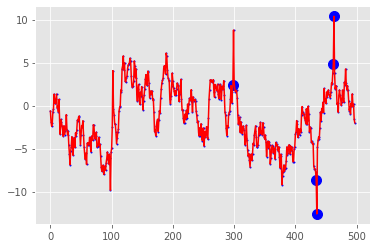

```python
import numpy as np
import matplotlib.pyplot as plt

#data
x = list(range(len(df1[0]+1)))
y = df1[0]
ysize = df1['label']


for i in range (0, len(x)):
    plt.plot(x[i], y[i], linestyle="None",marker="o", markersize=ysize[i], color="blue")

plt.plot(x, y, color="red")

plt.show()
```

## Time Series 2

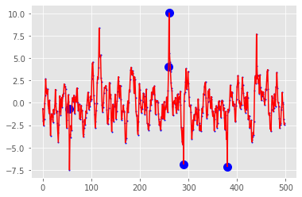

```python
import numpy as np
import matplotlib.pyplot as plt

#data
x = list(range(len(df2[0]+1)))
y = df2[0]
ysize = df2['label']


for i in range (0, len(x)):
    plt.plot(x[i], y[i], linestyle="None",marker="o", markersize=ysize[i], color="blue")

plt.plot(x, y, color="red")

plt.show()
```